# Statistics Assignment

Jordan Melson

2023-04-04

### Question 1 (20 pts)

Please describe the data you are using for your project in a couple sentences. What type of data is it and what does it look like? What are the objectives and hypotheses of your project? How do you plan to test this hypothesis (what types of statistics)?

The data for this project is 8 weeks worth of crape myrtle bark scale population counts from crape myrtles in the greenhouse. Adult and Crawler counts were taken weekly over 2 months on 36 trees with 6 different treatments. All data are physical, in-situ counts, taken by hand. The goal of the experiment was to determine if limonene, a botanical, had similar or better control of CMBS than common chemical insecticides including pyriproxifen, dinotefuran, and imidacloprid, as well as a water treatment and a non-treated control. Based on previous unpublished data, we hypothesize that limonene will meet or exceed our expectations. We plan to run the data as a generalized linear mixed model to account for repeated measures by including the individual tree as a random variable. This takes into account the variance in the number of CMBS from one tree to the next, and removes that variance from the variance attributed to the fixed effects of treatment and time. ### Question 2 (15 pts) Write the code to test your hypotheses and achieve the objectives in question 1.

```r
library(tidyverse)
library(lme4)
library(emmeans)
library(multcomp)
LimoR <- read.csv('LimoR.csv')

lm(Total~Trt*as.factor(Date), data = LimoR)
```

```
##
## Call:
## lm(formula = Total ~ Trt * as.factor(Date), data = LimoR)
##
## Coefficients:
##               (Intercept)                    TrtDino
##                   392.667                    101.500
##                   TrtImid                    TrtLimo
##                    70.000                     44.000
##                   TrtPyri                   TrtWater
##                    82.667                      7.667
##          as.factor(Date)1           as.factor(Date)2
##                   -82.500                    -89.333
##          as.factor(Date)3           as.factor(Date)4
##                   -91.500                     -7.833
##          as.factor(Date)5           as.factor(Date)6
##                    20.833                   -105.167
##          as.factor(Date)7           as.factor(Date)8
##                    13.500                     11.333
##  TrtDino:as.factor(Date)1   TrtImid:as.factor(Date)1
##                  -150.167                    140.000
##  TrtLimo:as.factor(Date)1   TrtPyri:as.factor(Date)1
##                   -87.167                    136.500
## TrtWater:as.factor(Date)1   TrtDino:as.factor(Date)2
##                   -65.333                   -132.167
##  TrtImid:as.factor(Date)2   TrtLimo:as.factor(Date)2
##                    54.500                   -166.333
##  TrtPyri:as.factor(Date)2  TrtWater:as.factor(Date)2
##                    37.167                    -16.167
##  TrtDino:as.factor(Date)3   TrtImid:as.factor(Date)3
##                  -186.333                    -29.167
##  TrtLimo:as.factor(Date)3   TrtPyri:as.factor(Date)3
##                  -183.667                   -155.167
## TrtWater:as.factor(Date)3   TrtDino:as.factor(Date)4
##                   -95.500                   -287.667
##  TrtImid:as.factor(Date)4   TrtLimo:as.factor(Date)4
##                   -11.500                   -420.000
##  TrtPyri:as.factor(Date)4  TrtWater:as.factor(Date)4
##                     3.000                    -21.167
##  TrtDino:as.factor(Date)5   TrtImid:as.factor(Date)5
##                  -333.500                   -105.333
##  TrtLimo:as.factor(Date)5   TrtPyri:as.factor(Date)5
##                  -419.000                   -207.000
## TrtWater:as.factor(Date)5   TrtDino:as.factor(Date)6
##                   -62.667                   -217.000
##  TrtImid:as.factor(Date)6   TrtLimo:as.factor(Date)6
##                   -69.000                   -297.667
##  TrtPyri:as.factor(Date)6  TrtWater:as.factor(Date)6
##                   -23.667                    -38.333
##  TrtDino:as.factor(Date)7   TrtImid:as.factor(Date)7
##                  -302.333                   -167.000
##  TrtLimo:as.factor(Date)7   TrtPyri:as.factor(Date)7
##                  -431.500                   -108.333
## TrtWater:as.factor(Date)7   TrtDino:as.factor(Date)8
##                  -264.833                   -371.000
##  TrtImid:as.factor(Date)8   TrtLimo:as.factor(Date)8
##                  -327.667                   -411.667
##  TrtPyri:as.factor(Date)8  TrtWater:as.factor(Date)8
##                  -289.167                   -154.167
```

```r
summary(Total~Trt, data = LimoR)
```

```
##  Length   Class    Mode
##       3 formula    call
```

```r
anova(lm(Total~Trt, data = LimoR))
```

```
## Analysis of Variance Table
##
## Response: Total
##            Df   Sum Sq Mean Sq F value    Pr(>F)
## Trt         5  2434578  486916  4.4661 0.0006016 ***
## Residuals 318 34669696  109024
## ---
## Signif. codes:  0 '***' 0.001 '**' 0.01 '*' 0.05 '.' 0.1 ' ' 1
```

```r
lm.trt <- lm(Total ~ Trt, data = LimoR)
summary(lm.trt)
```

```
##
## Call:
## lm(formula = Total ~ Trt, data = LimoR)
##
## Residuals:
##     Min      1Q  Median      3Q     Max
## -371.19 -230.66  -97.53  165.90 1435.59
##
## Coefficients:
##             Estimate Std. Error t value Pr(>|t|)
## (Intercept)   355.93      44.93   7.921 3.98e-14 ***
## TrtDino      -118.52      63.54  -1.865  0.06309 .
## TrtImid        12.76      63.54   0.201  0.84099
## TrtLimo      -224.56      63.54  -3.534  0.00047 ***
## TrtPyri        15.26      63.54   0.240  0.81038
## TrtWater      -72.13      63.54  -1.135  0.25719
## ---
## Signif. codes:  0 '***' 0.001 '**' 0.01 '*' 0.05 '.' 0.1 ' ' 1
##
## Residual standard error: 330.2 on 318 degrees of freedom
## Multiple R-squared:  0.06561,    Adjusted R-squared:  0.05092
## F-statistic: 4.466 on 5 and 318 DF,  p-value: 0.0006016
```

```r
lsmeans <- emmeans(lm.trt, ~Trt)
Results_lsmeans <- multcomp::cld(lsmeans, alpha = 0.05, reversed = TRUE, details = TRUE)
Results_lsmeans
```

```
## $emmeans
##  Trt     emmean   SE  df lower.CL upper.CL .group
##  Pyri       371 44.9 318      283      460  1
##  Imid       369 44.9 318      280      457  1
##  Control    356 44.9 318      268      444  1
##  Water      284 44.9 318      195      372  12
##  Dino       237 44.9 318      149      326  12
##  Limo       131 44.9 318       43      220   2
##
## Confidence level used: 0.95
## P value adjustment: tukey method for comparing a family of 6 estimates
## significance level used: alpha = 0.05
## NOTE: If two or more means share the same grouping symbol,
##       then we cannot show them to be different.
##       But we also did not show them to be the same.
##
## $comparisons
##  contrast        estimate   SE  df t.ratio p.value
##  Dino - Limo        106.0 63.5 318   1.669  0.5536
##  Water - Limo       152.4 63.5 318   2.399  0.1598
##  Water - Dino        46.4 63.5 318   0.730  0.9781
##  Control - Limo     224.6 63.5 318   3.534  0.0062
##  Control - Dino     118.5 63.5 318   1.865  0.4257
##  Control - Water     72.1 63.5 318   1.135  0.8664
##  Imid - Limo        237.3 63.5 318   3.735  0.0030
##  Imid - Dino        131.3 63.5 318   2.066  0.3080
##  Imid - Water        84.9 63.5 318   1.336  0.7648
##  Imid - Control      12.8 63.5 318   0.201  1.0000
##  Pyri - Limo        239.8 63.5 318   3.774  0.0026
##  Pyri - Dino        133.8 63.5 318   2.105  0.2872
##  Pyri - Water        87.4 63.5 318   1.375  0.7419
##  Pyri - Control      15.3 63.5 318   0.240  0.9999
##  Pyri - Imid          2.5 63.5 318   0.039  1.0000
##
## P value adjustment: tukey method for comparing a family of 6 estimates
```

###Question 3 (15 pts) Interpret your results. What do the results of your code mean, and how do you plan to show this in figures or table form?

Limonene is not significantly different from dinotefuran or water but is the only of those treatments that is significantly different from the other treatments.

```
## No summary function supplied, defaulting to `mean_se()`
```

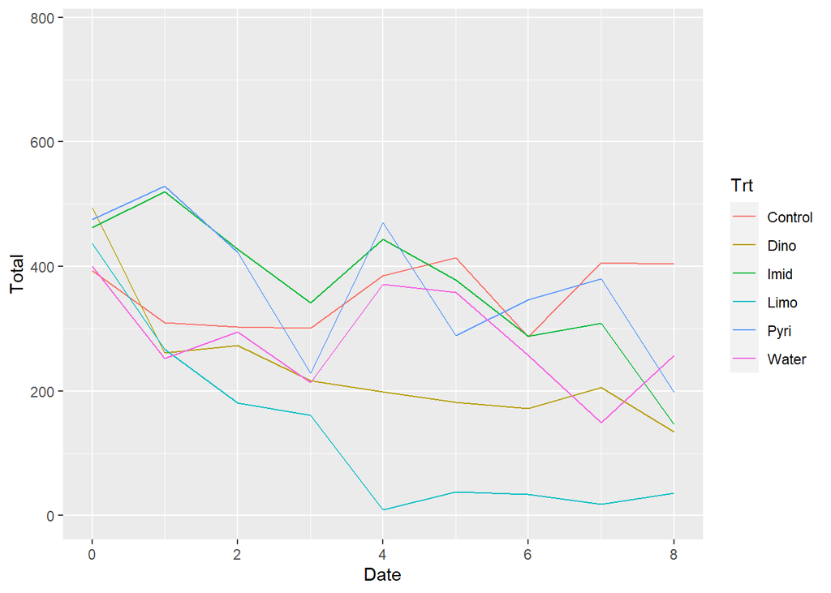

```r
library(ggplot2)

ggplot(LimoR, aes(x = Date, y = Total, group = Trt, color = Trt)) +
  stat_summary(geom ="line")
```

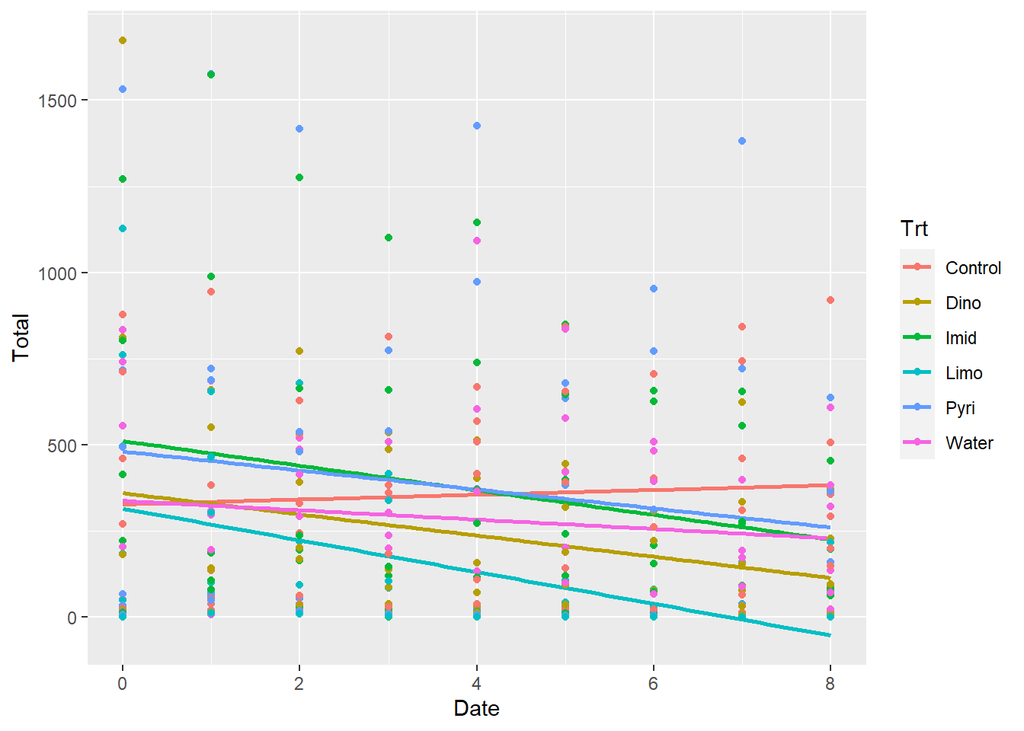

```r
ggplot(LimoR, aes(x = Date, y = Total, group = Trt, color = Trt)) +
  geom_smooth(method = lm, se = FALSE)+
  geom_point()
```